# Hydrolytic Extracellular Enzyme Pre-test Calculations

Hava Blair

June 18, 2020

## Enzyme Pre-test Calculations

## Read in plate templates

You need one completed template file for each plate, in CSV format. See https://github.com/havablair/plater-prep

## File organization

Place template files for each round in their own subfolder named “plater-templates-round#”, filling in # with the appropriate numeral.

Now you are ready to read in your files. If you get an error, check whether you have any extra CSV files in the designated folder.

## Read in plate templates & metadata

```r
file.names <- dir(glue("./data/temp/plater-templates-round{params$round}/"))
file.paths <- paste0(glue("./data/temp/plater-templates-round{params$round}/"),
    file.names)
plates <- read_plates(file.paths)
colnames(plates) <- c("plate", "wells", "id", "bad_wells",
    "conc_uM", "fluor")

plates
```

```
## # A tibble: 768 x 6
##    plate        wells id          bad_wells conc_uM fluor
##    <chr>        <chr> <chr>       <chr>     <chr>   <int>
##  1 1-rr120-8-bc A01   B-sub-blank <NA>      sub_300   998
##  2 1-rr120-8-bc A02   B-sub-blank <NA>      sub_300  1054
##  3 1-rr120-8-bc A03   C-sub-blank <NA>      sub_300   534
##  4 1-rr120-8-bc A04   C-sub-blank <NA>      sub_300   534
##  5 1-rr120-8-bc A05   B-Assay     <NA>      sub_300 11154
##  6 1-rr120-8-bc A06   B-Assay     <NA>      sub_300 10490
##  7 1-rr120-8-bc A07   C-Assay     <NA>      sub_300  1757
##  8 1-rr120-8-bc A08   C-Assay     <NA>      sub_300  1407
##  9 1-rr120-8-bc A09   MUB2.5+S    <NA>      mub_2.5 22088
## 10 1-rr120-8-bc A10   MUB2.5      <NA>      mub_2.5 27782
## # ... with 758 more rows
```

```r
# To check that all plates read in correctly
head(plates)
```

```
## # A tibble: 6 x 6
##   plate        wells id          bad_wells conc_uM fluor
##   <chr>        <chr> <chr>       <chr>     <chr>   <int>
## 1 1-rr120-8-bc A01   B-sub-blank <NA>      sub_300   998
## 2 1-rr120-8-bc A02   B-sub-blank <NA>      sub_300  1054
## 3 1-rr120-8-bc A03   C-sub-blank <NA>      sub_300   534
## 4 1-rr120-8-bc A04   C-sub-blank <NA>      sub_300   534
## 5 1-rr120-8-bc A05   B-Assay     <NA>      sub_300 11154
## 6 1-rr120-8-bc A06   B-Assay     <NA>      sub_300 10490
```

```r
unique(plates$plate)
```

```
## [1] "1-rr120-8-bc"  "2-rr120-8-np"  "3-rr120-7-bc"  "4-rr120-7-np"  "5-sw61-6.5-bc"
## [6] "6-sw61-6.5-np" "7-sw61-7-bc"   "8-sw61-7-np"
```

```r
# read in plate metadata
plate_metadata <- read.csv(glue("./data/metadata/eea_plate_metadata_pretest{params$round}.csv"),
    stringsAsFactors = FALSE)

colnames(plate_metadata) <- c("plate", "sample_id", "ph_buffer",
    "moist_soil_mass_g", "soil_water_content", "vol_buffer_ml",
    "substrates", "time_soil_added", "time_naoh_added",
    "time_plate_read")

head(plate_metadata)
```

```
##           plate  sample_id ph_buffer moist_soil_mass_g soil_water_content vol_buffer_ml
## 1  1-rr120-8-bc RR2_SH_A_3       8.0            1.0082               0.32            25
## 2  2-rr120-8-np RR2_SH_A_3       8.0            1.0082               0.32            25
## 3  3-rr120-7-bc RR2_SH_A_3       7.0            1.0002               0.32            25
## 4  4-rr120-7-np RR2_SH_A_3       7.0            1.0002               0.32            25
## 5 5-sw61-6.5-bc SW1_SH_A_3       6.5            1.0056               0.32            25
## 6 6-sw61-6.5-np SW1_SH_A_3       6.5            1.0056               0.32            25
##   substrates time_soil_added time_naoh_added time_plate_read
## 1        B-C           12:21           13:21           13:23
## 2        N-P           12:23           13:24           13:25
## 3        B-C           12:05           13:07           13:10
## 4        N-P           12:09           13:08           13:10
## 5        B-C           12:18           13:20           13:21
## 6        N-P           12:16           13:18           13:19
```

# Metadata calculations

## Incubation time, soil oven dry equivalent

```r
# parse the time columns so we can do math on them
plate_metadata <- plate_metadata %>% mutate(time_soil_added = parse_hm(time_soil_added),
    time_naoh_added = parse_hm(time_naoh_added), time_plate_read = parse_hm(time_plate_read))

# calculate incubation time and convert from seconds to
# hours
plate_metadata <- plate_metadata %>% mutate(inc_time_hr = as.numeric(((time_plate_read -
    time_soil_added)/60/60)))


# calculate soil oven dry equivalent

plate_metadata <- plate_metadata %>% mutate(soil_ov_dry_eq_g = moist_soil_mass_g -
    (moist_soil_mass_g * soil_water_content))

plate_metadata
```

```
##           plate  sample_id ph_buffer moist_soil_mass_g soil_water_content vol_buffer_ml
## 1  1-rr120-8-bc RR2_SH_A_3       8.0            1.0082               0.32            25
## 2  2-rr120-8-np RR2_SH_A_3       8.0            1.0082               0.32            25
## 3  3-rr120-7-bc RR2_SH_A_3       7.0            1.0002               0.32            25
## 4  4-rr120-7-np RR2_SH_A_3       7.0            1.0002               0.32            25
## 5 5-sw61-6.5-bc SW1_SH_A_3       6.5            1.0056               0.32            25
## 6 6-sw61-6.5-np SW1_SH_A_3       6.5            1.0056               0.32            25
## 7   7-sw61-7-bc SW1_SH_A_3       7.0            1.0023               0.32            25
## 8   8-sw61-7-np SW1_SH_A_3       7.0            1.0023               0.32            25
##   substrates time_soil_added time_naoh_added time_plate_read inc_time_hr soil_ov_dry_eq_g
## 1        B-C        12:21:00        13:21:00        13:23:00    1.033333         0.685576
## 2        N-P        12:23:00        13:24:00        13:25:00    1.033333         0.685576
## 3        B-C        12:05:00        13:07:00        13:10:00    1.083333         0.680136
## 4        N-P        12:09:00        13:08:00        13:10:00    1.016667         0.680136
## 5        B-C        12:18:00        13:20:00        13:21:00    1.050000         0.683808
## 6        N-P        12:16:00        13:18:00        13:19:00    1.050000         0.683808
## 7        B-C        12:12:00        13:13:00        13:14:00    1.033333         0.681564
## 8        N-P        12:14:00        13:15:00        13:16:00    1.033333         0.681564
```

# Initial Quality Control

## Remove empty wells and known bad wells

```r
# Remove empty wells
no_missing <- subset(plates, !is.na(id) & id != 0 & id !=
    ".")

# Remove bad wells and keep good ones
no_bad <- subset(no_missing, is.na(bad_wells))

no_missing$bad_wells
```

[output not shown]

[output cut: 40 more lines]

```r
# Create a dataframe with the details about which wells
# were removed as 'bad'.  Can write this to CSV now, or
# wait until after later QC checks to compile a list of
# samples that need to be redone.
bad_list <- subset(no_missing, !is.na(bad_wells))

wells_removed <- nrow(plates) - nrow(no_bad)

glue("Removed {wells_removed} wells that were missing or bad")
```

```
## Removed 18 wells that were missing or bad
```

```r
clean_data <- no_bad

clean_nested <- clean_data %>% group_by(plate) %>% nest()

head(clean_nested)
```

```
## # A tibble: 6 x 2
## # Groups:   plate [6]
##   plate         data
##   <chr>         <list>
## 1 1-rr120-8-bc  <tibble [91 x 5]>
## 2 2-rr120-8-np  <tibble [92 x 5]>
## 3 3-rr120-7-bc  <tibble [93 x 5]>
## 4 4-rr120-7-np  <tibble [95 x 5]>
## 5 5-sw61-6.5-bc <tibble [93 x 5]>
## 6 6-sw61-6.5-np <tibble [96 x 5]>
```

# Calculate plate blank and homogenate blank (hombl)

```r
# function to calculate plate blank mean fluor
get_plate_blank <- function(data) {
    buf <- data %>% filter(id == "Buf")
    mean(buf$fluor)
}

# apply function to nested dataframe
plate_blanks <- clean_nested %>% mutate(plate_blank = map_dbl(data,
    get_plate_blank))

# function to calculate homogenate blank (Buf +s) mean
# fluor
get_hombl <- function(data) {
    buf_soil <- data %>% filter(id == "Buf+s")
    mean(buf_soil$fluor)
}

# apply function to nested dataframe
hombl_calcs <- plate_blanks %>% mutate(hombl = map_dbl(data,
    get_hombl))

hombl_calcs$data
```

```
## [[1]]
## # A tibble: 91 x 5
##    wells id          bad_wells conc_uM fluor
##    <chr> <chr>       <chr>     <chr>   <int>
##  1 A01   B-sub-blank <NA>      sub_300   998
##  2 A02   B-sub-blank <NA>      sub_300  1054
##  3 A03   C-sub-blank <NA>      sub_300   534
##  4 A04   C-sub-blank <NA>      sub_300   534
##  5 A05   B-Assay     <NA>      sub_300 11154
##  6 A06   B-Assay     <NA>      sub_300 10490
##  7 A07   C-Assay     <NA>      sub_300  1757
##  8 A08   C-Assay     <NA>      sub_300  1407
##  9 A09   MUB2.5+S    <NA>      mub_2.5 22088
## 10 A10   MUB2.5      <NA>      mub_2.5 27782
## # ... with 81 more rows
##
## [[2]]
## # A tibble: 92 x 5
##    wells id          bad_wells conc_uM fluor
##    <chr> <chr>       <chr>     <chr>   <int>
##  1 A01   N-sub-blank <NA>      sub_300   649
##  2 A02   N-sub-blank <NA>      sub_300   671
##  3 A03   P-sub-blank <NA>      sub_300  7404
##  4 A04   P-sub-blank <NA>      sub_300  7500
##  5 A05   N-Assay     <NA>      sub_300  1181
##  6 A06   N-Assay     <NA>      sub_300  1134
##  7 A07   P-Assay     <NA>      sub_300 23786
##  8 A08   P-Assay     <NA>      sub_300 22466
##  9 A09   MUB2.5+S    <NA>      mub_2.5 22967
## 10 A10   MUB2.5      <NA>      mub_2.5 27184
## # ... with 82 more rows
##
## [[3]]
## # A tibble: 93 x 5
##    wells id          bad_wells conc_uM fluor
##    <chr> <chr>       <chr>     <chr>   <int>
##  1 A01   B-sub-blank <NA>      sub_300   869
##  2 A02   B-sub-blank <NA>      sub_300   817
##  3 A03   C-sub-blank <NA>      sub_300   521
##  4 A04   C-sub-blank <NA>      sub_300   509
```

[output cut: 72 more lines]

```
## [[8]]
## # A tibble: 96 x 5
##    wells id          bad_wells conc_uM fluor
##    <chr> <chr>       <chr>     <chr>   <int>
##  1 A01   N-sub-blank <NA>      sub_300   531
##  2 A02   N-sub-blank <NA>      sub_300   565
##  3 A03   P-sub-blank <NA>      sub_300  6225
##  4 A04   P-sub-blank <NA>      sub_300  6412
##  5 A05   N-Assay     <NA>      sub_300  1228
##  6 A06   N-Assay     <NA>      sub_300  1210
##  7 A07   P-Assay     <NA>      sub_300 10902
##  8 A08   P-Assay     <NA>      sub_300 18158
##  9 A09   MUB2.5+S    <NA>      mub_2.5  3543
## 10 A10   MUB2.5      <NA>      mub_2.5 14558
## # ... with 86 more rows
```

## MUB Standard calculations (for emission coeff calc)

Calculate the mean fluorescence for each concentration of MUB standard (no soil). Subtract the plate blank to calculate the corrected fluorescence value for the MUB standards.

```r
mub_std_fun <- function(data) {
    data %>% select(wells, id, fluor, conc_uM) %>% filter(str_detect(wells,
        "10")) %>% group_by(id) %>% summarise(mub_std_mean = mean(fluor),
        n = n())  #Add CV here?
}

mub_stds <- hombl_calcs %>% mutate(mub_std_values = map(data,
    mub_std_fun))
# Can always include an 'unnest' option here for quick
# viewing of the plate numbers and standards


# Subtract the plate blank from the fluorescence values
# for each averaged concentration

corr_stds <- mub_stds %>% unnest(mub_std_values) %>% mutate(corr_fluor = mub_std_mean -
    plate_blank, conc_uM = as.numeric(str_replace(id, "MUB",
    ""))) %>% nest(std_data = c(id, mub_std_mean, n, corr_fluor,
    conc_uM))
```

## MUB + Soil Standards

Calculate the mean fluorescence of MUB + soil at each MUB concentration and correct the fluor using the homogenate blank values.

```r
# Average the MUB+soil wells to get mean fluorescence
# for each concentration and calculate corrected value
# by subtracting the fluor of the homogenate blank.
quench_std_fun <- function(data, hombl) {
    data %>% select(wells, id, fluor, conc_uM) %>% filter(str_detect(wells,
        "09")) %>% mutate(conc_uM = as.numeric(str_replace(conc_uM,
        "mub_", ""))) %>% group_by(conc_uM) %>% summarise(quench_fluor = mean(fluor),
        n = n(), sd = sd(fluor), cv = (sd(fluor)/mean(fluor)) *
            100, corr_fluor = quench_fluor - hombl)
}

quench_stds <- corr_stds %>% mutate(quench_std_values = map2(data,
    hombl, quench_std_fun))
```

# Linear models

##Linear model functions

```r
# function to run a linear model x = MUB concentration,
# y = mean fluorescence

lm_mod_ftn <- function(df) {
    lm(corr_fluor ~ conc_uM, data = df)
}

# functions to extract linear model details calculated
# above into a nicer format for putting in our graphs

b_fun <- function(mod) {
    coefficients(mod)[[1]]
}

slope_fun <- function(mod) {
    coefficients(mod)[[2]]
}

r_sq_fun <- function(mod) {
    summary(mod)[["r.squared"]]
}

max_fluor_fun <- function(data) {
    max(data$corr_fluor)
}
```

## Linear model calculations

```r
# calculate linear model for both standard curves (MUB
# standards (emission) and MUB stds +soil (quench))
lm_calcs <- quench_stds %>% mutate(emis_lm = map(std_data,
    lm_mod_ftn), quench_lm = map(quench_std_values, lm_mod_ftn))

# Extract linear model details from the MUB standard
# (emission) linear model
emis_lm_details <- lm_calcs %>% mutate(intcpt_emis = map_dbl(emis_lm,
    b_fun), slope_emis = map_dbl(emis_lm, slope_fun), r_squared_emis = map_dbl(emis_lm,
    r_sq_fun), max_fluor_emis = map_dbl(std_data, max_fluor_fun))

# nest the linear model details in a dataframe
nest_emis_stats <- emis_lm_details %>% nest(lm_stats_emis = c(intcpt_emis,
    slope_emis, r_squared_emis, max_fluor_emis))

# Extract linear models details from the MUB std + soil
# (quench) linear model
quench_lm_details <- nest_emis_stats %>% mutate(intcpt_quench = map_dbl(quench_lm,
    b_fun), slope_quench = map_dbl(quench_lm, slope_fun),
    r_squared_quench = map_dbl(quench_lm, r_sq_fun), max_fluor_quench = map_dbl(quench_std_values,
        max_fluor_fun))

# nest the linear model details in a dataframe
nest_quench_stats <- quench_lm_details %>% nest(lm_stats_quench = c(intcpt_quench,
    slope_quench, r_squared_quench, max_fluor_quench))
```

## Plot MUB Standard Curve (emission)

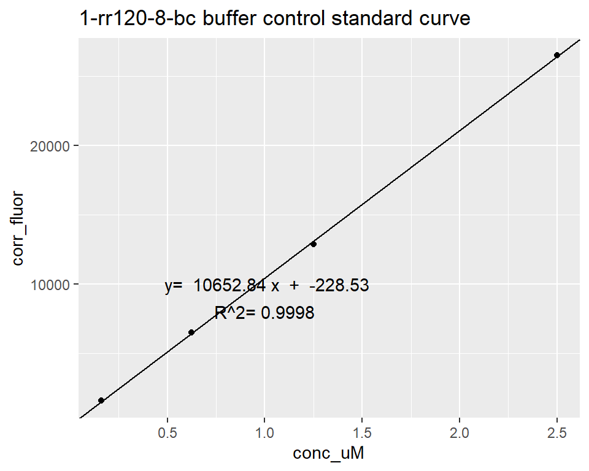

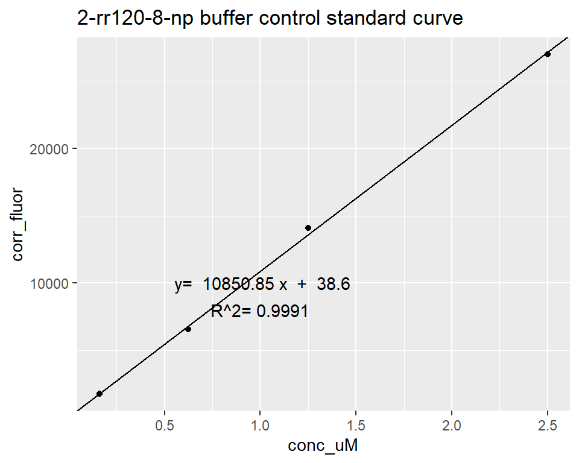

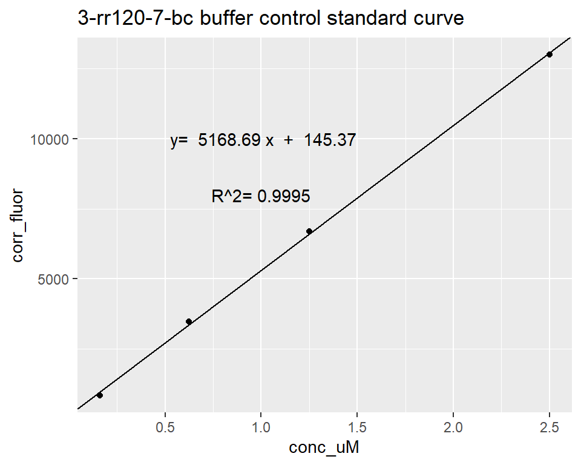

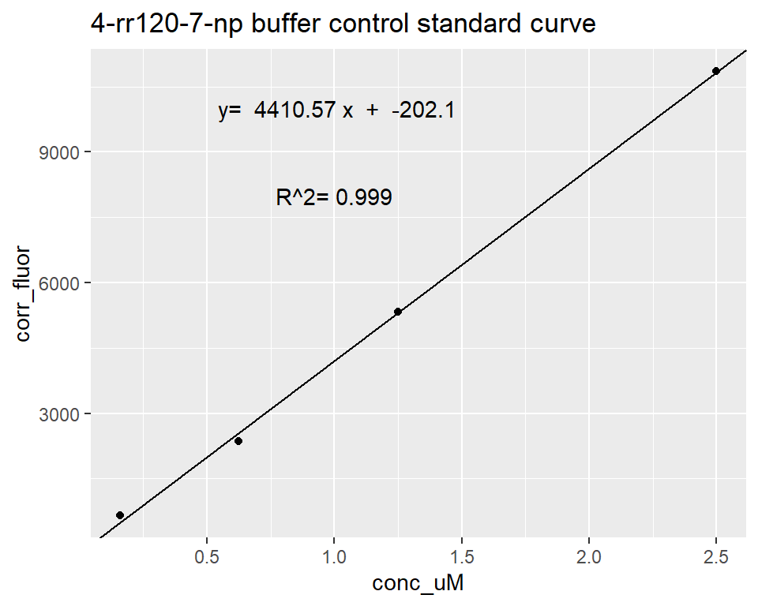

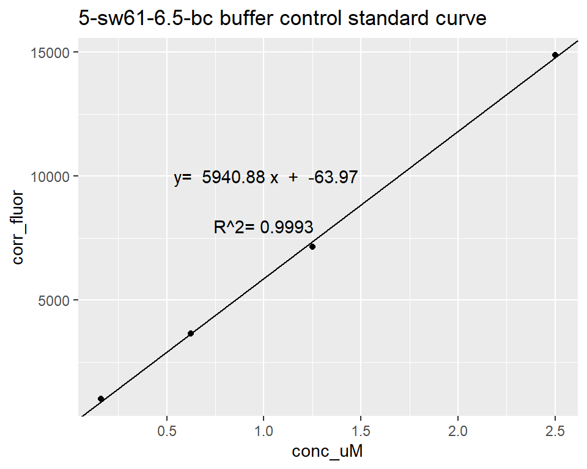

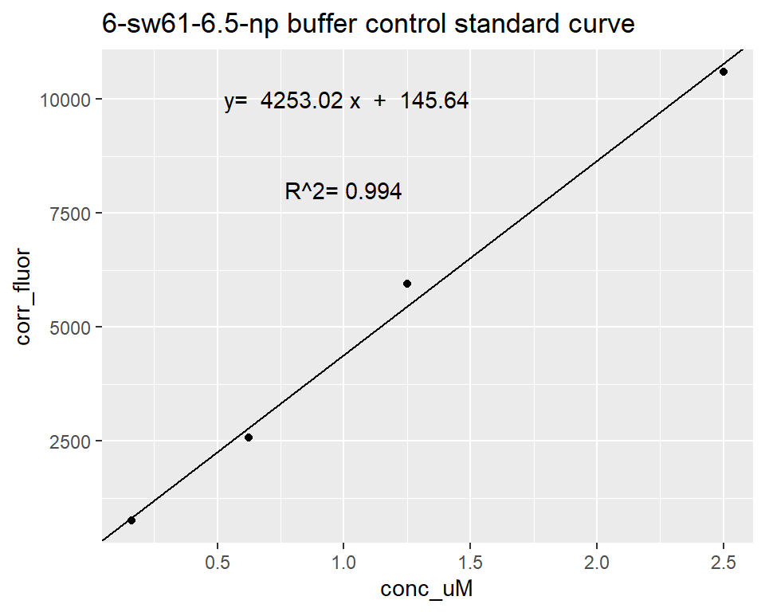

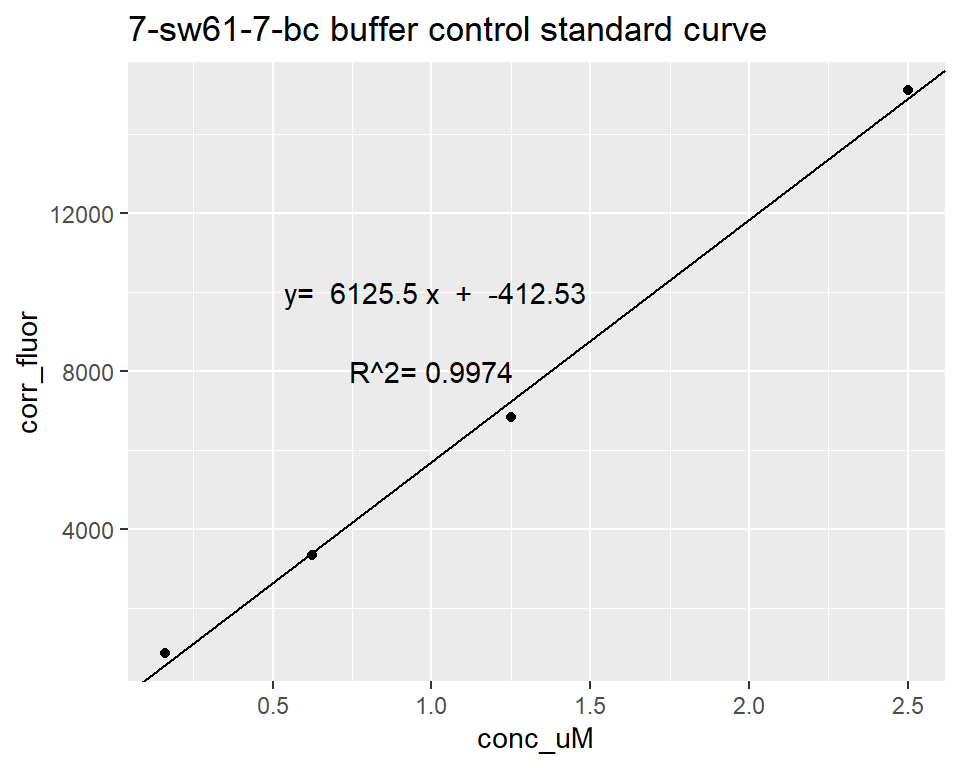

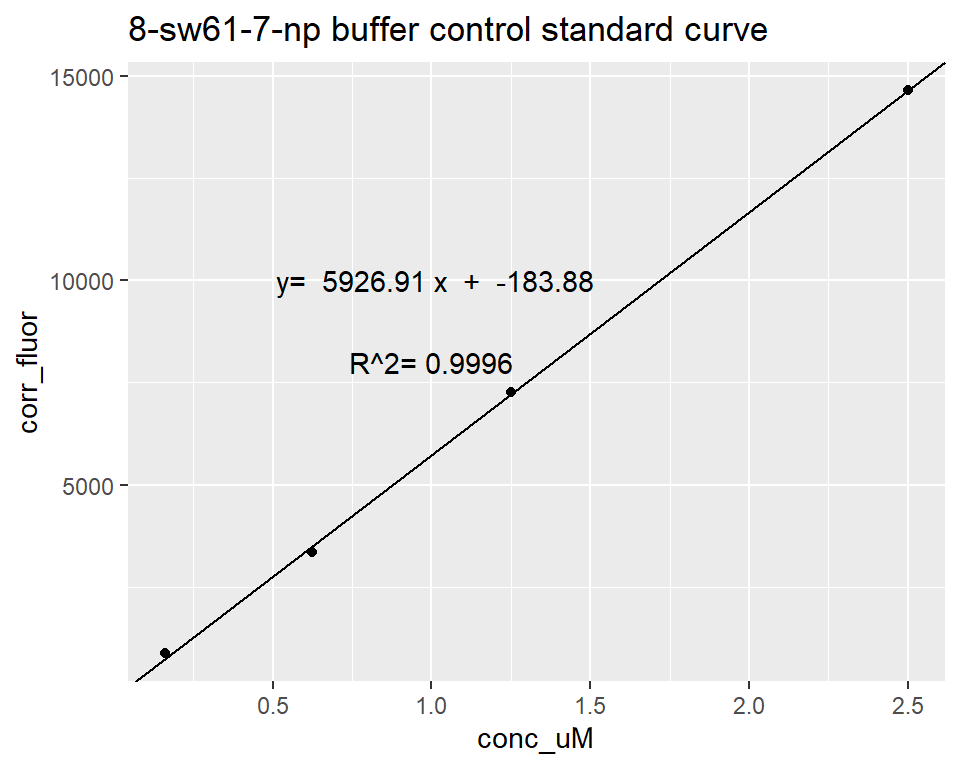

```r
# Function to make standard curve plots

plot_pts_fun <- function(std_data, lm_stats_emis, plate) {
    g <- ggplot() + geom_point(data = std_data, aes(x = conc_uM,
        y = corr_fluor)) + geom_abline(data = lm_stats_emis,
        aes(slope = slope_emis, intercept = intcpt_emis)) +
        geom_text(data = lm_stats_emis, aes(x = 1, y = 8000,
            label = paste("R^2=", round(r_squared_emis,
                digits = 4))), inherit.aes = FALSE) + geom_text(data = lm_stats_emis,
        aes(x = 1, y = 10000, label = paste(" y= ", round(slope_emis,
            digits = 2), "x", " + ", round(intcpt_emis,
            digits = 2))), inherit.aes = FALSE) + labs(title = glue("{plate} buffer control standard curve"))
    return(g)
}


plot_test <- nest_quench_stats %>% mutate(plot_buffer_control = pmap(list(std_data,
    lm_stats_emis, plate), plot_pts_fun))

plot_test$plot_buffer_control
```

## Plot MUB standard + soil standard curve (quench)

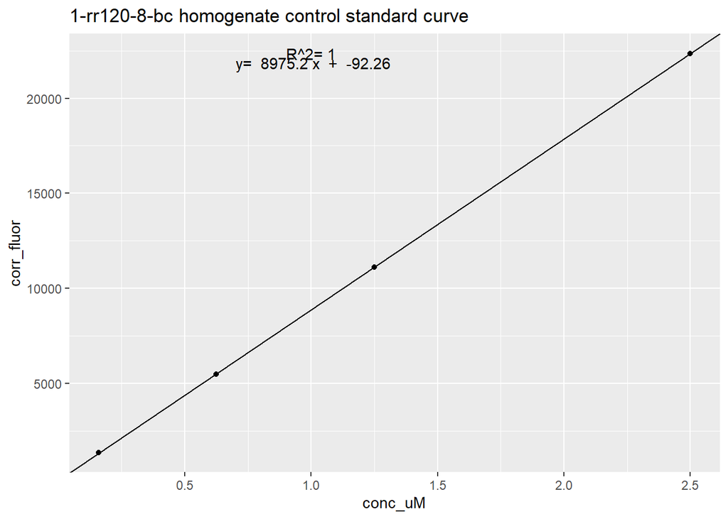

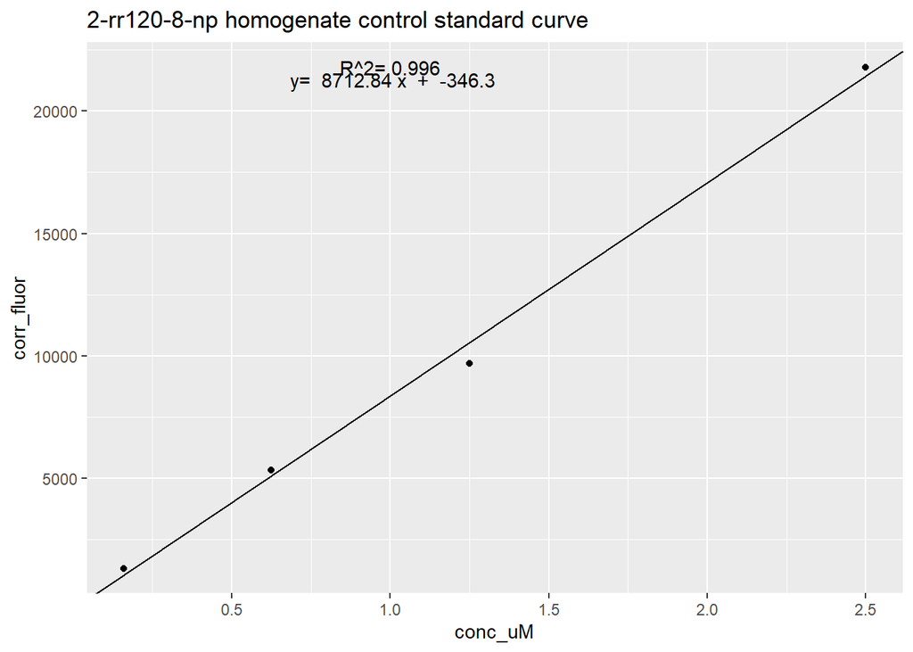

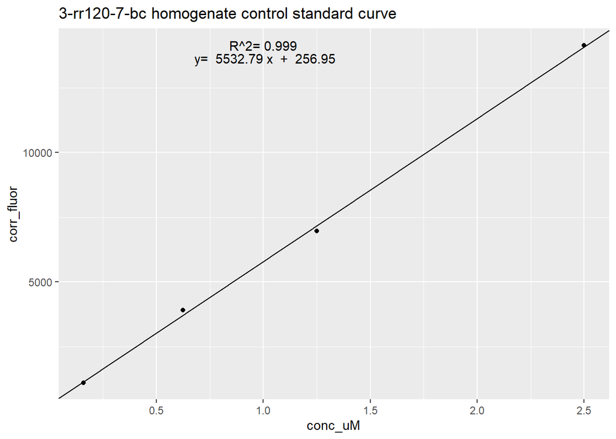

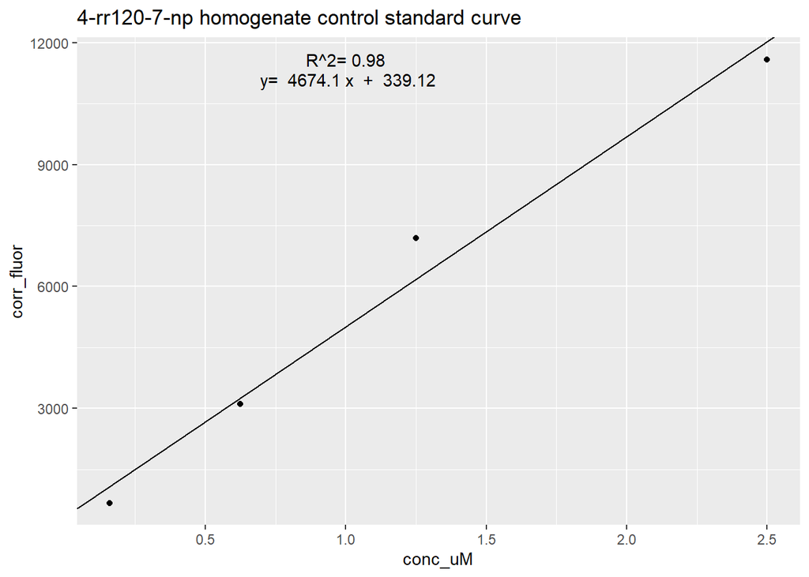

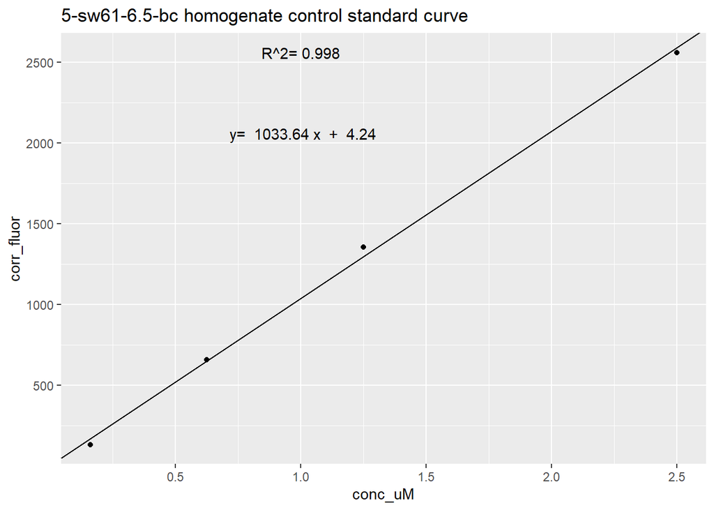

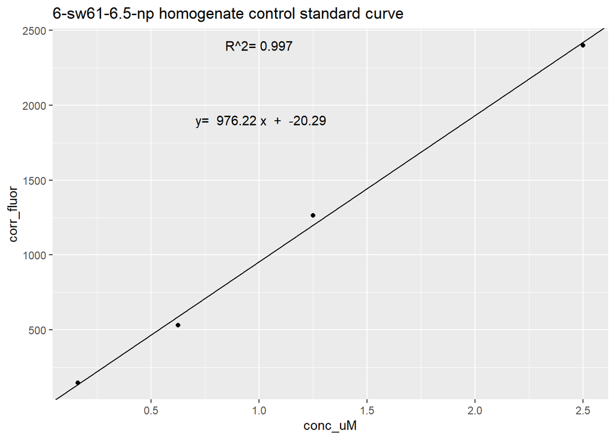

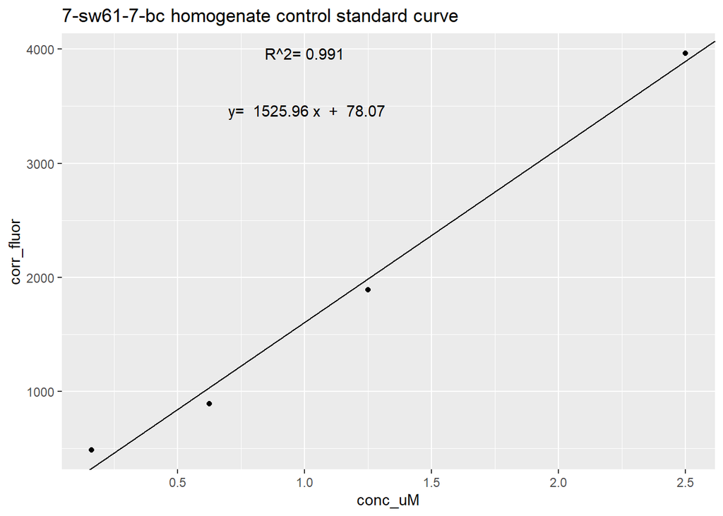

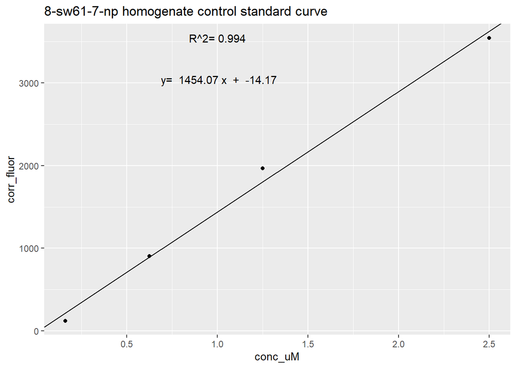

```r
plot_homog_fun <- function(quench_std_values, lm_stats_quench,
    plate) {
    g <- ggplot() + geom_point(data = quench_std_values,
        aes(x = conc_uM, y = corr_fluor)) + geom_abline(data = lm_stats_quench,
        aes(slope = slope_quench, intercept = intcpt_quench)) +
        geom_text(data = lm_stats_quench, aes(x = 1, y = (max_fluor_quench),
            label = paste("R^2=", round(r_squared_quench,
                digits = 3))), inherit.aes = FALSE) + geom_text(data = lm_stats_quench,
        aes(x = 1, y = (max_fluor_quench - 500), label = paste(" y= ",
            round(slope_quench, digits = 2), "x", " + ",
            round(intcpt_quench, digits = 2))), inherit.aes = FALSE) +
        labs(title = glue("{plate} homogenate control standard curve"))
    return(g)
}

homog_plots <- plot_test %>% mutate(plot_homog_control = pmap(list(quench_std_values,
    lm_stats_quench, plate), plot_homog_fun))

homog_plots$plot_homog_control
```